# Presentation: Data Science Final Paper

Kshitij Kshitij

2024-06-13

# Introduction

The authors highlight the challenges of progressive taxation in low- and middle-income countries, focusing on statutory incidence, tax evasion, and economic incidence of taxes .

## Objectives

- To demonstrate accurate reproducability of Figure 1 from the academic paper provided
- To write a report using Quarto and R Markdown
- Publish the report as a website through GitHub
- Showcase challenges and issues face during replication of result.

## Figure 1

- The figure depicts how the total share of GDP collected in taxes evolves from lower-income to higher-income countries.
- Total Tax Revenue: Increases with economic development, indicating higher tax collection capabilities in wealthier countries.

## Dataset

- The data for Figure 1 was compiled from various primary micro-datasets, which are detailed in the “Cross-Country Data” sheet of the “Data Sources” document in the replication package.
- This dataset is created by running the `Master_cross_country.do` file, which harmonizes income and employment variables and merges them with other relevant datasets(Bachas et al., 2024).

## Dataset

- The dataset includes 132 countries with populations over one million and excludes those where revenue from oil and gas exceeds one-third of GDP. This sample covers 93 percent of the world’s population. The data for 2018 were compiled from various sources, including individual countries’ government archives, the OECD, and UNU-WIDER/ICTD which were compiled into “Master_crosscty.dta” (Bachas et al., 2024).

## Dataset

Variables used from dataset

- gdp_pc, ndp_usd = GDP per Capita
- pct_tax, relyear_incometax = Total Tax Revenue

## Code

- Install packages, load libraries
- Set working directory and input dataset

```r
if (!require(pacman)) install.packages("pacman")
suppressMessages(pacman::p_unload(all))
pacman::p_load(tidyverse,haven,dplyr)

setwd("C:/HSF/data sciene/final")
data2 <- read_dta("Master_crosscty.dta")
data <- read_csv("globalETR_bfjz.csv")
```

## Code

Mutate data to preferred variables

```r
data <- data %>%
  mutate(GDP_per_capita = ndp_usd / 1000000,
         Total_Tax_Revenue = pct_tax
         )
```

## Code

Plot Graph

```r
plot <- ggplot(data, aes(x = GDP_per_capita, y = pct_tax)) +
  geom_point() +
  scale_x_log10() +
  labs(
    title = "Total tax revenue (excl. SSC)",
    x = "GDP per capita (constant 2010 US dollars, log scale)",
    y = "Share of GDP"
  ) +
  theme_minimal() +
  theme(
    plot.title = element_text(hjust = 0.5),
    legend.position = "bottom"
  )
```

## Code

```r
plot
```

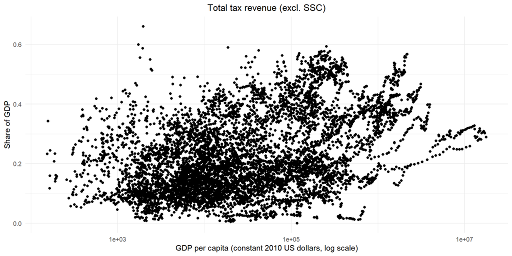

## Using Master_crosscty data package

```r
plot2
```

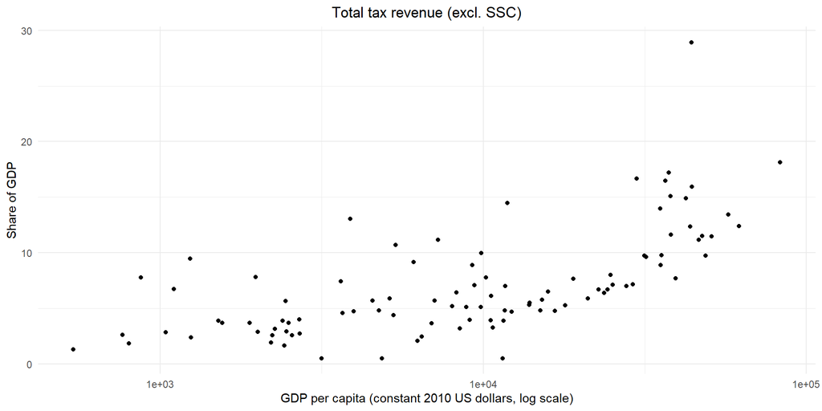

## Challenges

- Familiarizing with the dataset, understanding the variables, and their significance.
- Dealing with missing values in the dataset and filtering.
- Exact points not being depicted as shown in the result given on the paper.
- Faced many issues while pushing the presentation to Github.

## References

Pierre Bachas, Anders Jensen, and Lucie Gadenne. Tax equity in low- and middle-income countries. Journal of Economic Perspectives, 38(1):55–80, February 2024. doi: 10.1257/jep. 38.1.55. URL https://www.aeaweb.org/articles?id=10.1257/jep.38.1.55.

Bachas, Pierre, Matthew H. Fisher-Post, Anders Jensen, and Gabriel Zucman. 2022c. “Database for: Globalization and Factor Income Taxation.” NBER Working Paper 29819. https://globaltaxation. world